# MonteCarlo 18

9 actividades triangulares; límite 3 operarios, plazo 23

# Enunciado

Considere el proyecto cuyo cuadro de prelaciones, duración de cada actividad (mínima *a*, más probable *m* y máxima *b*, en semanas, distribución triangular) y operarios necesarios se adjunta. Cada actividad necesita un número fijo de operarios durante toda su duración y la empresa dispone como máximo de 3 operarios por semana. El contrato exige terminar en **23 semanas**.

1. Calcule con las duraciones más probables la duración del proyecto sin límite de recursos y con el límite de operarios (algoritmo de asignación).

2. Simule 2000 réplicas: en cada una sortee las duraciones, calcule la duración sin recursos y **replanifique** con el límite. Compare media, desviación típica y percentil 90 de ambas distribuciones.

3. Estime la probabilidad de cumplir el plazo de 23 semanas ignorando los recursos y respetándolos. ¿Qué conclusión sacaría un director que solo mirase el camino crítico?

4. Calcule el índice de criticidad de cada actividad sin y con recursos, y la frecuencia con que el límite de operarios retrasa alguna actividad. ¿Qué actividades pasan a mandar al introducir el límite?

5. ¿Cómo cambia la probabilidad de cumplir si se amplía el límite en un operario? Decida si merece la pena.

Tabla 1: Cuadro de datos del enunciado

| activity | predecessor | a | m | b | operarios |
| --- | --- | --- | --- | --- | --- |
| A | --- | 1 | 3 | 5 | 1 |
| B | --- | 2 | 4 | 6 | 2 |
| C | --- | 5 | 6 | 9 | 2 |
| D | A | 6 | 8 | 10 | 3 |
| E | A | 3 | 4 | 6 | 3 |
| F | B,E | 2 | 4 | 6 | 3 |
| G | C,E | 5 | 7 | 8 | 2 |
| H | D,F | 3 | 4 | 6 | 3 |
| I | G,H | 3 | 5 | 8 | 3 |

# Resolución

## Apartado 1

1. Calcule con las duraciones más probables la duración del proyecto sin límite de recursos y con el límite de operarios (algoritmo de asignación).

Cálculo de los tiempos mínimos y máximos de los nodos del grafo Roy paso a paso. El primer paso muestra el grafo resuelto; a partir del siguiente se calcula desde el principio (avance con los botones):

[figure not shown]

paso 0 de 24

[figure not shown]

Figura 1: Grafo Roy con las duraciones más probables y el camino crítico (sin límite)

Tabla 2: Calendario sin límite de recursos

[figure not shown]

ninguna celda (0 de 72)

[figure not shown]

Haz clic en un número de la tabla para ver cómo se calcula.

👆 **Interactivo:** haz clic en cualquier celda de la tabla para ver cómo se calcula (otro clic la deselecciona), o usa los botones y las flechas del teclado.

| Actividad | Duración | Inicio más temprano | Fin más temprano | Inicio más tardío | Fin más tardío | H total | H libre | H independiente |
| --- | --- | --- | --- | --- | --- | --- | --- | --- |
| A | 3 | 0 | 3 | 0 | 3 | 0 | 0 | 0 |
| B | 4 | 0 | 4 | 3 | 7 | 3 | 3 | 3 |
| C | 6 | 0 | 6 | 2 | 8 | 2 | 1 | 1 |
| D | 8 | 3 | 11 | 3 | 11 | 0 | 0 | 0 |
| E | 4 | 3 | 7 | 3 | 7 | 0 | 0 | 0 |
| F | 4 | 7 | 11 | 7 | 11 | 0 | 0 | 0 |
| G | 7 | 7 | 14 | 8 | 15 | 1 | 1 | 0 |
| H | 4 | 11 | 15 | 11 | 15 | 0 | 0 | 0 |
| I | 5 | 15 | 20 | 15 | 20 | 0 | 0 | 0 |

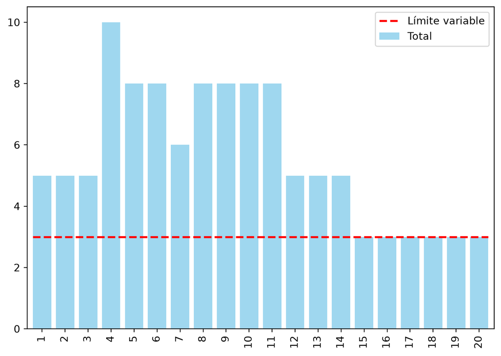

Figura 2: Carga de operarios con los inicios más tempranos frente al límite

El algoritmo de asignación recorre las semanas: cada actividad disponible (predecesoras terminadas) empieza, por orden de prioridad (menor inicio más tardío), si caben sus operarios durante toda su duración; si no, espera. Traza semana a semana y Gantt resultante (filas 💤: esperas):

Periodo 1. Empiezan: [‘A’, ‘C’]. Esperan: [‘B (operarios)’]

Periodo 2. Empiezan: []. Esperan: [‘B (operarios)’]

Periodo 3. Empiezan: []. Esperan: [‘B (operarios)’]

Periodo 4. Empiezan: []. Esperan: [‘B (operarios)’, ‘E (operarios)’, ‘D (operarios)’]

Periodo 5. Empiezan: []. Esperan: [‘B (operarios)’, ‘E (operarios)’, ‘D (operarios)’]

Periodo 6. Empiezan: []. Esperan: [‘B (operarios)’, ‘E (operarios)’, ‘D (operarios)’]

Periodo 7. Empiezan: [‘B’]. Esperan: [‘E (operarios)’, ‘D (operarios)’]

Periodo 8. Empiezan: []. Esperan: [‘E (operarios)’, ‘D (operarios)’]

Periodo 9. Empiezan: []. Esperan: [‘E (operarios)’, ‘D (operarios)’]

Periodo 10. Empiezan: []. Esperan: [‘E (operarios)’, ‘D (operarios)’]

Periodo 11. Empiezan: [‘E’]. Esperan: [‘D (operarios)’]

Periodo 12. Empiezan: []. Esperan: [‘D (operarios)’]

Periodo 13. Empiezan: []. Esperan: [‘D (operarios)’]

Periodo 14. Empiezan: []. Esperan: [‘D (operarios)’]

Periodo 15. Empiezan: [‘D’]. Esperan: [‘F (operarios)’, ‘G (operarios)’]

Periodo 16. Empiezan: []. Esperan: [‘F (operarios)’, ‘G (operarios)’]

Periodo 17. Empiezan: []. Esperan: [‘F (operarios)’, ‘G (operarios)’]

Periodo 18. Empiezan: []. Esperan: [‘F (operarios)’, ‘G (operarios)’]

Periodo 19. Empiezan: []. Esperan: [‘F (operarios)’, ‘G (operarios)’]

Periodo 20. Empiezan: []. Esperan: [‘F (operarios)’, ‘G (operarios)’]

Periodo 21. Empiezan: []. Esperan: [‘F (operarios)’, ‘G (operarios)’]

Periodo 22. Empiezan: []. Esperan: [‘F (operarios)’, ‘G (operarios)’]

Periodo 23. Empiezan: [‘F’]. Esperan: [‘G (operarios)’]

Periodo 24. Empiezan: []. Esperan: [‘G (operarios)’]

Periodo 25. Empiezan: []. Esperan: [‘G (operarios)’]

Periodo 26. Empiezan: []. Esperan: [‘G (operarios)’]

Periodo 27. Empiezan: [‘G’]. Esperan: [‘H (operarios)’]

Periodo 28. Empiezan: []. Esperan: [‘H (operarios)’]

Periodo 29. Empiezan: []. Esperan: [‘H (operarios)’]

Periodo 30. Empiezan: []. Esperan: [‘H (operarios)’]

Periodo 31. Empiezan: []. Esperan: [‘H (operarios)’]

Periodo 32. Empiezan: []. Esperan: [‘H (operarios)’]

Periodo 33. Empiezan: []. Esperan: [‘H (operarios)’]

Periodo 34. Empiezan: [‘H’]. Esperan: []

Periodo 38. Empiezan: [‘I’]. Esperan: []

[figure not shown]

Figura 3: Gantt con el límite de operarios y las duraciones más probables

Tabla 3: Inicio de cada actividad sin y con límite

|  | A | B | C | D | E | F | G | H | I |
| --- | --- | --- | --- | --- | --- | --- | --- | --- | --- |
| inicio sin límite | 0 | 0 | 0 | 3 | 3 | 7 | 7 | 11 | 15 |
| inicio con límite | 0 | 6 | 0 | 14 | 10 | 22 | 26 | 33 | 37 |
| fin con límite | 3 | 10 | 6 | 22 | 14 | 26 | 33 | 37 | 42 |
| espera (semanas) | 0 | 6 | 0 | 11 | 7 | 8 | 12 | 7 | 0 |

**Respuesta:** con las duraciones más probables el proyecto dura 20 semanas sin límite de recursos y 42 semanas con 3 operarios (las esperas de la tabla anterior lo retrasan 22).

## Apartado 2

2. Simule 2000 réplicas: en cada una sortee las duraciones, calcule la duración sin recursos y **replanifique** con el límite. Compare media, desviación típica y percentil 90 de ambas distribuciones.

En cada réplica se sortean las duraciones (triangulares, redondeadas a semanas enteras), se calcula la duración sin recursos (camino más largo) y se vuelve a aplicar el algoritmo de asignación con el límite: dos duraciones por réplica. `monte_carlo_recursos` hace las 2000 réplicas y guarda ambas. Los percentiles son los de las réplicas ordenadas (el P90 deja por debajo el 90 % de ellas).

Tabla 4: Distribución de la duración con y sin límite de recursos

|  | media | desv. típica | P5 | P50 | P90 | P95 |
| --- | --- | --- | --- | --- | --- | --- |
| sin recursos | 21.45 | 1.72 | 19.0 | 21.0 | 24.0 | 24.0 |
| con recursos | 43.36 | 2.40 | 39.0 | 43.0 | 46.0 | 47.0 |
| retraso por recursos | 21.91 | 1.82 | 19.0 | 22.0 | 24.0 | 25.0 |

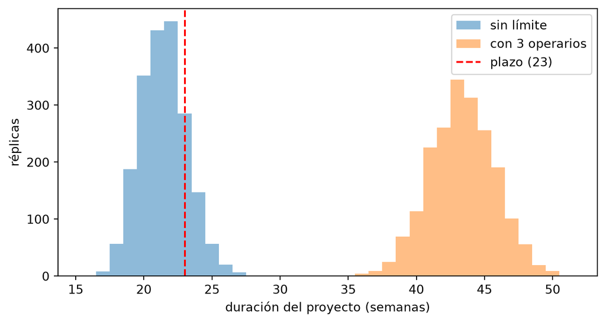

Figura 4: Distribución simulada de la duración sin y con el límite de operarios

**Respuesta:** la media sube de 21.45 a 43.36 semanas, la desviación típica pasa de 1.72 a 2.40 y el percentil 90 de 24 a 46 semanas. El límite añade esperas (de media 21.91 semanas) que dependen de qué actividades coinciden en cada réplica.

## Apartado 3

3. Estime la probabilidad de cumplir el plazo de 23 semanas ignorando los recursos y respetándolos. ¿Qué conclusión sacaría un director que solo mirase el camino crítico?

Sin recursos, 1769 de las 2000 réplicas terminan en 23 semanas o menos: P ≈ 1769/2000 = 0.884. Con el límite, 0 de 2000: P ≈ 0.000.

**Respuesta:** P(T ≤ 23) = 0.884 ignorando los recursos y 0.000 respetándolos. Un director que sólo mirase el camino crítico creería que cumple el plazo 88% de las veces, cuando con 3 operarios sólo lo cumple el 0.0%: el riesgo real de incumplir es 100.0% y no 11.6%.

## Apartado 4

4. Calcule el índice de criticidad de cada actividad sin y con recursos, y la frecuencia con que el límite de operarios retrasa alguna actividad. ¿Qué actividades pasan a mandar al introducir el límite?

El índice de criticidad de una actividad es el porcentaje de réplicas en que determina la duración: sin recursos, si está en la ruta más larga; con recursos, si forma parte de la cadena de actividades y esperas por el recurso que fija el final del proyecto.

Tabla 5: Criticidad sin y con recursos

|  | sin recursos | con recursos | cambio |
| --- | --- | --- | --- |
| C | 11.4 | 100.0 | 88.6 |
| H | 94.6 | 100.0 | 5.4 |
| D | 49.7 | 100.0 | 50.3 |
| E | 71.8 | 100.0 | 28.2 |
| F | 69.2 | 100.0 | 30.8 |
| I | 100.0 | 100.0 | 0.0 |
| G | 17.6 | 100.0 | 82.4 |
| B | 0.7 | 93.4 | 92.7 |
| A | 95.9 | 7.3 | -88.6 |

Tabla 6: Frecuencia con que cada recurso bloquea alguna actividad

|  | % de réplicas |
| --- | --- |
| operarios | 100.0 |

**Respuesta:** el límite de 3 operarios retrasa alguna actividad en el 100.0 % de las réplicas. Pasan a mandar (su índice sube 20 puntos o más) B (0.7 % → 93.4 %), C (11.4 % → 100.0 %), G (17.6 % → 100.0 %), D (49.7 % → 100.0 %), F (69.2 % → 100.0 %) y E (71.8 % → 100.0 %): en el CPM no siempre estaban en la ruta más larga, pero con el límite forman parte de la cadena de esperas por el recurso que fija el final del proyecto. En cambio pierden peso A (95.9 % → 7.3 %).

## Apartado 5

5. ¿Cómo cambia la probabilidad de cumplir si se amplía el límite en un operario? Decida si merece la pena.

Con 4 operarios P(T ≤ 23) pasa de 0.000 a 0.000; la media baja de 43.36 a 40.77 semanas.

**Respuesta:** Un operario más apenas mejora la probabilidad (+0.0 puntos, hasta 0.0%): por sí solo no resuelve el problema y sólo merecería la pena si es muy barato; hay que buscar otras medidas (más recursos, acortar actividades críticas o renegociar el plazo).